# Project_Final

# Plot the first vs. second principal component

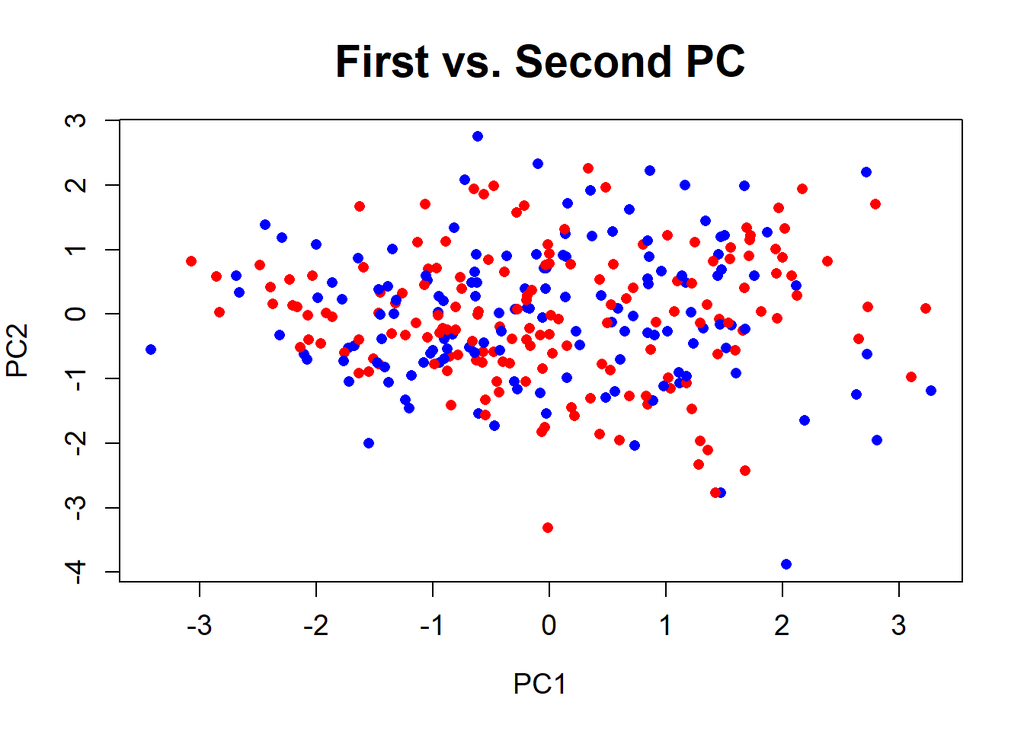

```r
# Define colors based on the first variable
colors <- c(rep("blue", 100), rep("red", 100))  # Adjust as per your actual data

# Plot the first vs. second principal component with dots
plot(x = pca$x[, 1], y = pca$x[, 2],
     pch = 16,  # Use a solid dot for better visualization
     col = colors,  # Use the defined colors
     xlab = "PC1", ylab = "PC2", main = "First vs. Second PC",
     cex.lab = 1.2, cex.axis = 1.2, cex.main = 1.8)
```

#Cluster_Analysis #K-Means Clustering

```r
uns_df <- scale(data2[,10:14])
head(as_tibble(uns_df))
```

```
## # A tibble: 6 × 5
##      age trestbps    chol thalach oldpeak
##    <dbl>    <dbl>   <dbl>   <dbl>   <dbl>
## 1 -0.268   -0.377 -0.659    0.821 -0.0609
## 2 -0.158    0.479 -0.833    0.256  1.73
## 3  1.72     0.764 -1.40    -1.05   1.30
## 4  0.724    0.936 -0.833    0.517 -0.912
## 5  0.834    0.365  0.930   -1.87   0.705
## 6  0.393   -1.80   0.0388  -1.18  -0.0609
```

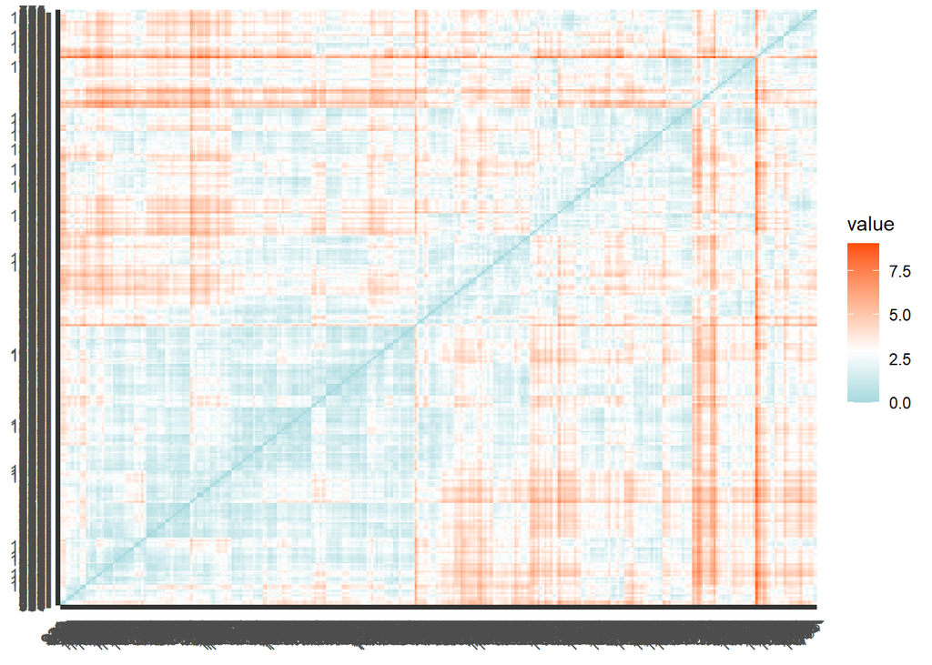

```r
# Calculate distances between observations using the standardized data
distance <- dist(uns_df)

# Visualize the distance matrix
fviz_dist(distance, gradient = list(low = "#00AFBB", mid = "white", high = "#FC4E07"))
```

```r
k2 <- kmeans(uns_df,
             center = 2,
             nstart = 25  )
str(k2)
```

```
## List of 9
##  $ cluster     : int [1:1025] 1 2 2 1 2 1 2 2 1 2 ...
##  $ centers     : num [1:2, 1:5] -0.518 0.708 -0.358 0.49 -0.268 ...
##   ..- attr(*, "dimnames")=List of 2
##   .. ..$ : chr [1:2] "1" "2"
##   .. ..$ : chr [1:5] "age" "trestbps" "chol" "thalach" ...
##  $ totss       : num 5120
##  $ withinss    : num [1:2] 1796 2057
##  $ tot.withinss: num 3854
##  $ betweenss   : num 1266
##  $ size        : int [1:2] 592 433
##  $ iter        : int 1
##  $ ifault      : int 0
##  - attr(*, "class")= chr "kmeans"
```

The output is from a k-means clustering analysis performed on a dataset with 1025 observations and 5 variables (age, trestbps, chol, thalach, and oldpeak). Two clusters were identified, labeled 1 and 2, with respective cluster centers indicating the average values of each variable within each cluster. The total sum of squares (totss) represents the total variability in the data, while withinss and betweenss denote the variability within and between clusters, respectively. The size of each cluster indicates the number of observations assigned to it. The iter parameter indicates the number of iterations performed during the clustering process, and ifault suggests no errors occurred during execution.

```r
k2
```

```
## K-means clustering with 2 clusters of sizes 592, 433
##
## Cluster means:
##          age   trestbps       chol    thalach    oldpeak
## 1 -0.5179893 -0.3580682 -0.2681813  0.4769983 -0.4557517
## 2  0.7081978  0.4895529  0.3666590 -0.6521547  0.6231062
##
## Clustering vector:
##    [1] 1 2 2 1 2 1 2 2 1 2 2 2 1 2 1 1 2 2 1 1 2 1 1 1 1 2 1 2 1 2 1 1 2 2 1 2 1
##   [38] 1 2 1 2 1 1 1 2 1 1 2 2 1 2 2 1 1 2 2 1 1 2 1 1 2 2 2 1 2 1 2 1 2 2 2 1 1
##   [75] 1 1 1 2 1 1 1 1 2 1 1 1 1 2 2 2 1 1 2 1 1 1 1 2 1 2 1 1 1 1 1 1 1 2 1 1 1
##  [112] 2 1 2 2 2 2 1 1 1 1 1 2 2 2 1 2 1 1 1 1 1 1 1 1 2 2 2 1 1 2 1 2 1 1 1 1 1
##  [149] 1 1 2 1 1 1 2 1 1 1 2 1 2 1 2 1 1 2 2 1 1 1 1 2 1 1 2 2 2 2 1 2 2 2 2 1 1
##  [186] 2 1 1 2 2 1 1 2 2 2 2 1 1 1 2 1 1 1 2 2 1 2 1 1 2 1 2 2 1 1 1 2 1 2 2 1 2
##  [223] 2 1 1 1 1 1 1 2 1 1 2 1 1 2 1 1 1 2 1 2 1 2 1 1 1 2 1 1 1 1 2 2 1 2 1 2 1
```

[output cut: 30 more lines]